# Accessing public data with trex (Terrestrial Rangeland data EXtraction)

Nelson Stauffer

2024-01-16

## Overview

The package [*trex*](https://github.com/landscape-data-commons/trex) can be used to retrieve publicly-available data directly from the [Landscape Data Commons (LDC)](https://landscapedatacommons.org) and [Ecosystem Dynamics Interpretive Tool (EDIT)](https://edit.jornada.nmsu.edu) APIs. This lets you programmatically query either source from R without having to construct your own API calls. Use cases include pulling monitoring data from the LDC for an area of interest or a specific ecological site and retrieving ecological site properties associated with data.

### Landscape Data Commons (LDC)

The Landscape Data Commons is a repository for multiple ecological data sets including data from the Bureau of Land Management (BLM) Assessment, Inventory, and Monitoring program ([AIM](https://www.blm.gov/aim)) and the Natural Resources Conservation Service ([NRCS](https://www.nrcs.usda.gov/)) Landscape Monitoring Framework (LMF). These are “raw” data from the field which have undergone quality control measures and are suitable for deriving ecological indicators, e.g., percent foliar cover or average sagebrush height.

### Ecosystem Dynamics Interpretive Tool (EDIT)

EDIT is a database containing Ecological Site Descriptions (ESDs) which define the properties associated with ecological sites. An ecological site is all the areas of a landscape which share geophysical and climatic properties and which produce similar kinds and amounts of vegetation. Knowing what ecological site a part of a landscape falls in can inform interpreting data from that area, e.g., having 10% of a location covered with vegetation means something very different on a steep, dry, gravelly slope than in a flat, loamy grassland.

## Querying the LDC

There are a few functions in *trex* which query the LDC, each of which is aimed at a different scenario. If you have a polygon or set of polygons and you want to retrieve data from sampling locations within them, you can use `fetch_ldc_spatial()`. If you want to retrieve data associated with one or more ecological sites, you can use `fetch_ldc_ecosite()`. For any other data retrieval, you can use the function that underpins those two, `fetch_ldc()`.

A critical reference for working with the LDC API is the [offical documentation](https://api.landscapedatacommons.org/api-docs). This lists the name of every data table you can query and the details of the variables each contains. You’ll need this page in order to know for sure how to ask for data, especially if you’re using `fetch_ldc()`.

### Retrieving data within a spatial extent using `fetch_ldc_spatial()`

The function `fetch_ldc_spatial()` was written to streamline querying the LDC using polygons. It compares your polygon(s) against the data locations and returns the requested data type associated with the locations falling within the polygon(s).

For this example, we’ll use the Jornada Experimental Range (JER) in southern New Mexico, shown in the map below.

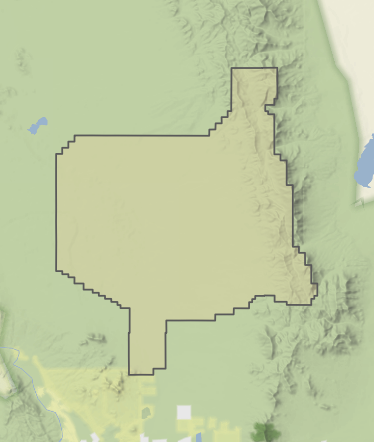

Because we’ve already loaded the JER boundary polygon as an sf polygon object using `sf::st_read()` and that’s what `fetch_ldc_spatial()` expects, we can easily ask for data from within that polygon. As a first example, we’ll simply ask for the header table, which contains the most basic information about the sampling locations, importantly their PrimaryKeys (which are unique to each location) and their coordinates.

```r
# The argument called polygons takes an sf polygon object while data_type takes
# the name of one of the tables that the LDC serves out.
# Note that the polygons are treated as a single unit, even if your object
# contained multiple or multipart polygons.
jer_headers <- trex::fetch_ldc_spatial(polygons = boundary_polygon,
                                       data_type = "header")
```

The first few rows of header results for the Jornada Experimental Range

|  | PrimaryKey | DBKey | ProjectKey | DateVisited | Latitude_NAD83 | Longitude_NAD83 | LocationType | EcologicalSiteID | PercentCoveredByEcoSite | SpeciesKey | PlotID | DateLoadedInDb | source | rid |
| --- | --- | --- | --- | --- | --- | --- | --- | --- | --- | --- | --- | --- | --- | --- |
| 586 | 06051514053759212006-04-19 | MURV_2003topresent_DIMA5pt5_11May2021ANON_DatesEdited | MURV | 2006-04-19T00:00:00.000Z | 32.5630 | -106.521 | NA | R042XB021NM | NA | MURV | 1 | 2023-04-10T00:00:00.000Z | AIM | 53507 |
| 587 | 06051514053759212007-03-09 | MURV_2003topresent_DIMA5pt5_11May2021ANON_DatesEdited | MURV | 2007-03-09T00:00:00.000Z | 32.5630 | -106.521 | NA | R042XB021NM | NA | MURV | 1 | 2023-04-10T00:00:00.000Z | AIM | 53508 |
| 633 | 0608111515207342006-06-20 | MURV_2003topresent_DIMA5pt5_11May2021ANON_DatesEdited | MURV | 2006-06-20T00:00:00.000Z | 32.5426 | -106.641 | NA | R042XB014NM | NA | MURV | 5SEG | 2023-04-10T00:00:00.000Z | AIM | 53554 |
| 649 | 07030911462583082006-04-24 | MURV_2003topresent_DIMA5pt5_11May2021ANON_DatesEdited | MURV | 2006-04-24T00:00:00.000Z | 32.5771 | -106.535 | NA | R042XB021NM | NA | MURV | 7 | 2023-04-10T00:00:00.000Z | AIM | 53570 |
| 650 | 0608111515207342007-02-08 | MURV_2003topresent_DIMA5pt5_11May2021ANON_DatesEdited | MURV | 2007-02-08T00:00:00.000Z | 32.5426 | -106.641 | NA | R042XB014NM | NA | MURV | 5SEG | 2023-04-10T00:00:00.000Z | AIM | 53571 |
| 651 | 06081115231717862006-06-07 | MURV_2003topresent_DIMA5pt5_11May2021ANON_DatesEdited | MURV | 2006-06-07T00:00:00.000Z | 32.5427 | -106.641 | NA | R042XB014NM | NA | MURV | 5SEB | 2023-04-10T00:00:00.000Z | AIM | 53572 |

The header table is nice, but is usually just a starting point or used specifically for map making. If you wanted to use the headers for anything spatial, you’d need to convert it into an sf points object.

```r
# The function sf::st_as_sf() will convert a data frame that includes coordinates
# into an sf object.
# In this case, we have the coordinates in the North American Datum 1983 (NAD83)
# Coordinate Reference System so we'll tell it which variables have the latitude
# and longitude values and that the CRS code is 4269 (that is, NAD83)
jer_points <-  sf::st_as_sf(x = jer_headers,
                            coords = c("Longitude_NAD83",
                                       "Latitude_NAD83"),
                            crs = 4269)
```

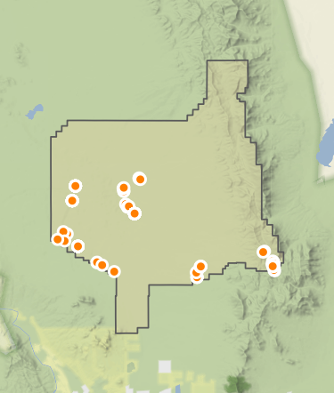

However, the headers on their own aren’t very useful. Luckily, we can also use `fetch_ldc_spatial()` to grab other kinds of data from the LDC associated with our polygon, including the already-computed standard AIM indicators and raw data from data collection methods like Line-Point Intercept, Gap Intercept, Soil Aggregate Stability, Vegetation Height, and Species Richness.

```r
# The LDC functions in trex can retrieve from only one data table at a time, so
# you'd need a different function call for each. This code will ask for the
# computed indicators.
jer_indicators <- trex::fetch_ldc_spatial(polygons = boundary_polygon,
                                          data_type = "indicators")

# And this will pull the raw LPI data that was used to compute the cover indicators
# that we just got in jer_indicators
jer_lpi <- trex::fetch_ldc_spatial(polygons = boundary_polygon,
                                   data_type = "lpi",
                                   # This argument asks the API to give the data
                                   # back in chunks of 5000 records at a time
                                   # so that we don't overwhelm the server, but
                                   # we'll still get all the data.
                                   take = 5000)
```

The first few rows of indicator results for the Jornada Experimental Range

| rid | PrimaryKey | DBKey | ProjectKey | DateVisited | EcologicalSiteId | PercentCoveredByEcoSite | Latitude_NAD83 | Longitude_NAD83 | LocationStatus | LocationType | Latitude_NAD83_Actual | Longitude_NAD83_Actual | BareSoilCover | TotalFoliarCover | AH_AnnGrassCover | AH_ForbCover | AH_GrassCover | AH_PerenForbCover | AH_PerenForbGrassCover | AH_PerenGrassCover | AH_ShrubCover | FH_CyanobacteriaCover | FH_DepSoilCover | FH_DuffCover | FH_EmbLitterCover | FH_HerbLitterCover | FH_LichenCover | FH_MossCover | FH_RockCover | … |
| --- | --- | --- | --- | --- | --- | --- | --- | --- | --- | --- | --- | --- | --- | --- | --- | --- | --- | --- | --- | --- | --- | --- | --- | --- | --- | --- | --- | --- | --- | --- |
| 50794 | 06051514053759212006-04-19 | MURV_2003topresent_DIMA5pt5_11May2021ANON_DatesEdited | MURV | 2006-04-19T00:00:00.000Z | R042XB021NM | NA | 32.563 | -106.521 | NA | NA | NA | NA | 3.75000 | 48.75000 | 0 | 7.50000 | 2.50000 | 0.0000000 | 2.50000 | 2.50000 | 0.000000 | 0 | 0 | 0 | 0 | 17.50000 | 0.0000000 | 0 | 28.7500000 | … |
| 50795 | 06051514053759212007-03-09 | MURV_2003topresent_DIMA5pt5_11May2021ANON_DatesEdited | MURV | 2007-03-09T00:00:00.000Z | R042XB021NM | NA | 32.563 | -106.521 | NA | NA | NA | NA | NA | NA | NA | NA | NA | NA | NA | NA | NA | 0 | 0 | 0 | 0 | NA | NA | 0 | NA | … |
| 50841 | 0608111515207342006-06-20 | MURV_2003topresent_DIMA5pt5_11May2021ANON_DatesEdited | MURV | 2006-06-20T00:00:00.000Z | R042XB014NM | NA | 32.5426 | -106.641 | NA | NA | NA | NA | 25.71429 | 54.28571 | 0 | 32.14286 | 23.57143 | 0.7142857 | 24.28571 | 23.57143 | 12.142857 | 0 | 0 | 0 | 0 | 17.85714 | 0.7142857 | 0 | 0.7142857 | … |
| 50857 | 07030911462583082006-04-24 | MURV_2003topresent_DIMA5pt5_11May2021ANON_DatesEdited | MURV | 2006-04-24T00:00:00.000Z | R042XB021NM | NA | 32.5771 | -106.535 | NA | NA | NA | NA | NA | NA | NA | NA | NA | NA | NA | NA | NA | 0 | 0 | 0 | 0 | NA | NA | 0 | NA | … |
| 50858 | 0608111515207342007-02-08 | MURV_2003topresent_DIMA5pt5_11May2021ANON_DatesEdited | MURV | 2007-02-08T00:00:00.000Z | R042XB014NM | NA | 32.5426 | -106.641 | NA | NA | NA | NA | 41.66667 | 31.66667 | 0 | 15.00000 | 15.00000 | 0.0000000 | 15.00000 | 15.00000 | 8.333333 | 0 | 0 | 0 | 0 | 25.00000 | 0.0000000 | 0 | 1.6666667 | … |
| 50859 | 06081115231717862006-06-07 | MURV_2003topresent_DIMA5pt5_11May2021ANON_DatesEdited | MURV | 2006-06-07T00:00:00.000Z | R042XB014NM | NA | 32.5427 | -106.641 | NA | NA | NA | NA | 87.50000 | 10.62500 | 0 | 0.00000 | 1.25000 | 0.0000000 | 1.25000 | 1.25000 | 9.375000 | 0 | 0 | 0 | 0 | 0.62500 | 0.0000000 | 0 | 1.2500000 | … |

The first few rows of raw LPI data results for the Jornada Experimental Range

| rid | PrimaryKey | DBKey | ProjectKey | LineKey | RecKey | layer | code | chckbox | ShrubShape | FormType | FormDate | Direction | Measure | LineLengthAmount | SpacingIntervalAmount | SpacingType | ShowCheckbox | CheckboxLabel | PointLoc | PointNbr | source | DateLoadedInDb | DateVisited |
| --- | --- | --- | --- | --- | --- | --- | --- | --- | --- | --- | --- | --- | --- | --- | --- | --- | --- | --- | --- | --- | --- | --- | --- |
| 15476001 | 06051514053759212006-04-19 | MURV_2003topresent_DIMA5pt5_11May2021ANON_DatesEdited | MURV | 060515142023987 | 0605151421162721 | TopCanopy | ERIOG | 1 | NA | NA | 2006-04-19T00:00:00.000Z | 288 | 1 | 20 | 25 | cm | 1 | Dead | 1 | 3 | AIM | 2023-04-10T00:00:00.000Z | 2006-04-19T00:00:00.000Z |
| 15476002 | 06051514053759212006-04-19 | MURV_2003topresent_DIMA5pt5_11May2021ANON_DatesEdited | MURV | 060515142023987 | 0605151421162721 | TopCanopy | AF03 | 0 | NA | NA | 2006-04-19T00:00:00.000Z | 288 | 1 | 20 | 25 | cm | 1 | Dead | 1 | 4 | AIM | 2023-04-10T00:00:00.000Z | 2006-04-19T00:00:00.000Z |
| 15476003 | 06051514053759212006-04-19 | MURV_2003topresent_DIMA5pt5_11May2021ANON_DatesEdited | MURV | 060515142023987 | 0605151421162721 | TopCanopy | ERIOG | 0 | NA | NA | 2006-04-19T00:00:00.000Z | 288 | 1 | 20 | 25 | cm | 1 | Dead | 2 | 7 | AIM | 2023-04-10T00:00:00.000Z | 2006-04-19T00:00:00.000Z |
| 15476004 | 06051514053759212006-04-19 | MURV_2003topresent_DIMA5pt5_11May2021ANON_DatesEdited | MURV | 060515142023987 | 0605151421162721 | TopCanopy | OPUNT | 0 | NA | NA | 2006-04-19T00:00:00.000Z | 288 | 1 | 20 | 25 | cm | 1 | Dead | 2 | 8 | AIM | 2023-04-10T00:00:00.000Z | 2006-04-19T00:00:00.000Z |
| 15476005 | 06051514053759212006-04-19 | MURV_2003topresent_DIMA5pt5_11May2021ANON_DatesEdited | MURV | 060515142023987 | 0605151421162721 | TopCanopy | BOGR2 | 0 | NA | NA | 2006-04-19T00:00:00.000Z | 288 | 1 | 20 | 25 | cm | 1 | Dead | 3 | 11 | AIM | 2023-04-10T00:00:00.000Z | 2006-04-19T00:00:00.000Z |
| 15476006 | 06051514053759212006-04-19 | MURV_2003topresent_DIMA5pt5_11May2021ANON_DatesEdited | MURV | 060515142023987 | 0605151421162721 | TopCanopy | JUMO | 0 | NA | NA | 2006-04-19T00:00:00.000Z | 288 | 1 | 20 | 25 | cm | 1 | Dead | 6 | 23 | AIM | 2023-04-10T00:00:00.000Z | 2006-04-19T00:00:00.000Z |

### Retrieving data associated with ecological sites using fetch_ldc_ecosite()

Another way to ask for data from the LDC is by ecological site ID with `fetch_ldc_ecosite()`. This function is just a convenient wrapper that queries to find *all* the PrimaryKey values associated with the requested ecological site IDs in the header table and then queries the data table with those PrimaryKey values. The end result is that you can get data by ecological site from data tables that don’t include ecological site IDs.

```r
# This will return all of the Canopy Gap data from sampling that occurred at
# locations that were identified as falling in the ecological sites R036XB006NM
# and R036XB007NM which are found in and around the San Luis Valley in northern
# New Mexico.
ecosites_gap <- trex::fetch_ldc_ecosite(keys = c("R036XB006NM", "R036XB007NM"),
                                        data_type = "gap")
```

The first few rows of raw gap data results for the ecological sites R036XB006NM and R036XB007NM

| rid | PrimaryKey | DBKey | ProjectKey | RecType | SeqNo | GapStart | GapEnd | Gap | LineKey | RecKey | FormDate | DateModified | FormType | Direction | Measure | LineLengthAmount | GapMin | GapData | PerennialsCanopy | AnnualGrassesCanopy | AnnualForbsCanopy | OtherCanopy | Notes | NoCanopyGaps | NoBasalGaps | DateLoadedInDb | PerennialsBasal | AnnualGrassesBasal | AnnualForbsBasal | … |
| --- | --- | --- | --- | --- | --- | --- | --- | --- | --- | --- | --- | --- | --- | --- | --- | --- | --- | --- | --- | --- | --- | --- | --- | --- | --- | --- | --- | --- | --- | --- |
| 5935061 | 14082610213641122014-09-01 | NM_TaosFO_LUP_2014_5-3b_01.mdb | BLM_AIM | C | 3010 | 2490 | 2458 | 32 | 1408261021381812 | 140826110307332 | 2014-08-25T00:00:00.000Z | NA | NA | NA | 1 | 25 | 20 | 2 | 1 | 1 | 1 | 1 | NA | 0 | 0 | 2023-10-31T00:00:00.000Z | 0 | 0 | 0 | … |
| 5935062 | 14082610213641122014-09-01 | NM_TaosFO_LUP_2014_5-3b_01.mdb | BLM_AIM | C | 3011 | 2430 | 2369 | 61 | 1408261021381812 | 140826110307332 | 2014-08-25T00:00:00.000Z | NA | NA | NA | 1 | 25 | 20 | 2 | 1 | 1 | 1 | 1 | NA | 0 | 0 | 2023-10-31T00:00:00.000Z | 0 | 0 | 0 | … |
| 5935063 | 14082610213641122014-09-01 | NM_TaosFO_LUP_2014_5-3b_01.mdb | BLM_AIM | C | 3012 | 2328 | 2289 | 39 | 1408261021381812 | 140826110307332 | 2014-08-25T00:00:00.000Z | NA | NA | NA | 1 | 25 | 20 | 2 | 1 | 1 | 1 | 1 | NA | 0 | 0 | 2023-10-31T00:00:00.000Z | 0 | 0 | 0 | … |
| 5935064 | 14082610213641122014-09-01 | NM_TaosFO_LUP_2014_5-3b_01.mdb | BLM_AIM | C | 3013 | 2258 | 2214 | 44 | 1408261021381812 | 140826110307332 | 2014-08-25T00:00:00.000Z | NA | NA | NA | 1 | 25 | 20 | 2 | 1 | 1 | 1 | 1 | NA | 0 | 0 | 2023-10-31T00:00:00.000Z | 0 | 0 | 0 | … |
| 5935065 | 14082610213641122014-09-01 | NM_TaosFO_LUP_2014_5-3b_01.mdb | BLM_AIM | C | 3014 | 2168 | 2102 | 66 | 1408261021381812 | 140826110307332 | 2014-08-25T00:00:00.000Z | NA | NA | NA | 1 | 25 | 20 | 2 | 1 | 1 | 1 | 1 | NA | 0 | 0 | 2023-10-31T00:00:00.000Z | 0 | 0 | 0 | … |
| 5935066 | 14082610213641122014-09-01 | NM_TaosFO_LUP_2014_5-3b_01.mdb | BLM_AIM | C | 3015 | 2090 | 2045 | 45 | 1408261021381812 | 140826110307332 | 2014-08-25T00:00:00.000Z | NA | NA | NA | 1 | 25 | 20 | 2 | 1 | 1 | 1 | 1 | NA | 0 | 0 | 2023-10-31T00:00:00.000Z | 0 | 0 | 0 | … |

### Retrieving data using key values using fetch_ldc()

The core function for querying the LDC is `fetch_ldc()`. It’s used for building all the LDC API queries, including those being sent by `fetch_ldc_spatial()` and `fetch_ldc_ecosite()` and, while not quite as flexible as hand writing the queries, is much more convenient. The basic idea is that you specify the data table you want data from and then values to restrict the results you get back, like applying a filter on the server side. The values are referred to as “keys” and can be applied to any variable in the table you’re asking for data from.

```r
# There are a few common use cases for fetch_ldc()

# If you wanted computed indicators, but only from within New Mexico and Colorado
# then you could ask for that data table but only where the values "NM" and "CO"
# are found in the variable called State.
nm_co_indicators <- trex::fetch_ldc(keys = c("NM", "CO"),
                                    key_type = "State",
                                    data_type = "indicators")

# So, we should have plots only from those two states now
table(nm_co_indicators$State)
```

```
##
##   CO   NM
## 5369 3583
```

Currently, keys must be discrete values, so there’s no way to ask for something like “sampling locations with greater than 50% bare ground” with numeric values. The best approach to approximate that is to grab more data than you may actually need and then keeping only the data that match your criteria, e.g., retrieving all New Mexico data then using something like `dplyr::filter()` to keep only records where bare ground was greater than 50%. The section “Chaining queries” addresses that.

You can, however, use partial matching. This can be useful for if, for example, you want to pull data associated with an MLRA, the code for which is embedded in the ecological site ID assigned to the data.

```r
# We can ask if our keys are part of the values in a variable (key_type)
# So, if we wanted sampling locations associated with MLRA 036X, we could use
# the partial matching feature to look for data where "036X" is part of the
# ecological site ID
mlra_036x_headers <- trex::fetch_ldc(keys = "036X",
                                     key_type = "EcologicalSiteID",
                                     data_type = "header",
                                     take = 10000,
                                     # This is the trick! By saying we don't
                                     # need an *exact* match it'll find all the
                                     #data where EcologicalSiteID includes "036x"
                                     exact_match = FALSE)
```

The first few rows of header results for the MLRA code 036X

| PrimaryKey | DBKey | ProjectKey | DateVisited | Latitude_NAD83 | Longitude_NAD83 | LocationType | EcologicalSiteID | PercentCoveredByEcoSite | SpeciesKey | PlotID | DateLoadedInDb | source | rid |
| --- | --- | --- | --- | --- | --- | --- | --- | --- | --- | --- | --- | --- | --- |
| 14070213253214082014-09-01 | NM_TaosFO_LUP_2014_5-3b_01.mdb | BLM_AIM | 2014-07-01T00:00:00.000Z | 36.57837 | -105.7062 | NA | R036XA004NM | NA | NM | Gravelly Slopes - 34 | 2023-10-31T00:00:00.000Z | TerrADat | 86451 |
| 14070709325347222014-09-01 | NM_TaosFO_LUP_2014_5-3b_01.mdb | BLM_AIM | 2014-07-06T00:00:00.000Z | 36.55372 | -105.7110 | NA | R036XA004NM | NA | NM | Gravelly Slopes - 35 | 2023-10-31T00:00:00.000Z | TerrADat | 86454 |
| 14070713180527932014-09-01 | NM_TaosFO_LUP_2014_5-3b_01.mdb | BLM_AIM | 2014-07-06T00:00:00.000Z | 36.54583 | -105.7175 | NA | R036XA004NM | NA | NM | Gravelly Slopes - 33 | 2023-10-31T00:00:00.000Z | TerrADat | 86455 |
| 14061710003068302014-09-01 | NM_TaosFO_LUP_2014_5-3b_01.mdb | BLM_AIM | 2014-06-16T00:00:00.000Z | 36.72645 | -105.9641 | NA | R036XB007NM | NA | NM | No Agua - 01 | 2023-10-31T00:00:00.000Z | TerrADat | 86457 |
| 14061910405233662014-09-01 | NM_TaosFO_LUP_2014_5-3b_01.mdb | BLM_AIM | 2014-06-18T00:00:00.000Z | 36.72151 | -105.8358 | NA | R036XB006NM | NA | NM | Cerrito Negro - 01 | 2023-10-31T00:00:00.000Z | TerrADat | 86460 |
| 14060211354634232014-09-01 | NM_TaosFO_LUP_2014_5-3b_01.mdb | BLM_AIM | 2014-06-01T00:00:00.000Z | 36.69129 | -105.6874 | NA | R036XB006NM | NA | NM | Wild River West - 01 | 2023-10-31T00:00:00.000Z | TerrADat | 86462 |